## Мазур Анастасия Вадимовна, 316

# Анализ данных, связанных с баскетбольными игроками NBA

Данное задание необходимо было реализовать на собственных данных. Я захотела проанализировать такой датасет, тема которого мне близка и интересна.  
К тому же, эти данные очень понятны, конкретны и показательны. Это позволяет самостоятельно выдвигать логичные гипотезы и проверять результаты на правдоподобность.

Устанавливаем необходимые библиотеки Python для дальнейшей работы.

```r
# Python
import pip
pip.main(["install", "matplotlib"])
pip.main(["install", "scikit-learn"])
pip.main(["install", "scikit-image"])
pip.main(["install", "umap-learn"])
pip.main(["install", "n5py"])
pip.main(["install", "pingouin"])
pip.main(["install", "hyperopt"])
pip.main(["install", "ipywidgets"])
pip.main(["install", "keras"])
pip.main(["install", "lightgbm"])
pip.main(["install", "numpy"])
pip.main(["install", "outlier_utils"])
pip.main(["install", "pandas"])
pip.main(["install", "plotly"])
pip.main(["install", "scipy"])
pip.main(["install", "seaborn"])
pip.main(["install", "scikit"])
pip.main(["install", "torch"])
pip.main(["install", "torchvision"])
pip.main(["install", "tqdm"])
pip.main(["install", "umap"])
pip.main(["install", "xgboost"])
pip.main(["install", "pep8"])
pip.main(["install", "statsmodels"])
import matplotlib
import numpy as np
import pandas as pd
import matplotlib.pyplot as plt
import seaborn as sns
import warnings
import scipy
from scipy import stats
warnings.simplefilter("ignore")
sns.set(style="darkgrid")
%matplotlib inline
my_color = '#6852A3'
warnings.filterwarnings("ignore") # не вывожу предупреждающие сообщения
```

Скачиваем функции, которые могут нам понадобиться для работы на языке R:

```r
# R
# Выключаю вывод предупреждающих сообщений warning
oldw <- getOption("warn")
options(warn = -1)

install.packages("dplyr")
install.packages("Hmisc")
install.packages("ggplot2")
install.packages("highcharter")
install.packages("Leaflet")
install.packages("RColorBrewer")
install.packages("Plotly")
install.packages("sunburstR")
install.packages("RGL")
install.packages("dygraphs")
install.packages("outliers")
library(outliers)
install.packages("mice")
library(mice)
install.packages("corrplot")
library(corrplot)
install.packages('car')
library(car)

packages <- c('ggplot2', 'dplyr', 'tidyr', 'tibble')
library(tidyr)
library(tibble)

install.packages("nortest")
library(nortest)
install.packages("ggpubr")
set.seed(31600) # устанавливаю значение рандома по умолчанию

filter_data = function(data_frame, column, value){
  dplyr::filter(data_frame, !!as.symbol(column) == value)
}
```

Данные я брала из открытого источника DatasetHub.  
В разных заданиях датасеты отличаются. Это потому что одни таблицы мне казались более удобными для реализации конкретного задания, потому что имели больше необходимых мне данных, которые я хотела рассмотреть, проанализировать и визуализировать.  
Давайте же ознакомимся с этими таблицами.

`NBA_STATS`  
Табличка с характеристиками игроков и их основными игровыми показателями.  
В таблице 490 записей про действующих на данный момент игроков NBA.

```r
# Python
nba_stats = pd.read_csv("/Users/mazur/Desktop/PRAK_5sem/nba/players_stats.csv")
nba_stats
```

|  | Name | Games Played | MIN | PTS | FGM | FGA | FG% | 3PM | 3PA | 3P% | ... | Age | Birth_Place | Birthdate | Collage | Experience | Height | Pos | Team | Weight | BMI |
| --- | --- | --- | --- | --- | --- | --- | --- | --- | --- | --- | --- | --- | --- | --- | --- | --- | --- | --- | --- | --- | --- |
| 0 | AJ Price | 26 | 324 | 133 | 51 | 137 | 37.2 | 15 | 57 | 26.3 | ... | 29.0 | us | October 7, 1986 | University of Connecticut | 5 | 185.0 | PG | PHO | 81.45 | 23.798393 |
| 1 | Aaron Brooks | 82 | 1885 | 954 | 344 | 817 | 42.1 | 121 | 313 | 38.7 | ... | 30.0 | us | January 14, 1985 | University of Oregon | 6 | 180.0 | PG | CHI | 72.45 | 22.361111 |
| 2 | Aaron Gordon | 47 | 797 | 243 | 93 | 208 | 44.7 | 13 | 48 | 27.1 | ... | 20.0 | us | September 16, 1995 | University of Arizona | R | 202.5 | PF | ORL | 99.00 | 24.142661 |
| 3 | Adreian Payne | 32 | 740 | 213 | 91 | 220 | 41.4 | 1 | 9 | 11.1 | ... | 24.0 | us | February 19, 1991 | Michigan State University | R | 205.0 | PF | ATL | 106.65 | 25.377751 |
| 4 | Al Horford | 76 | 2318 | 1156 | 519 | 965 | 53.8 | 11 | 36 | 30.6 | ... | 29.0 | do | June 3, 1986 | University of Florida | 7 | 205.0 | C | ATL | 110.25 | 26.234384 |
| ... | ... | ... | ... | ... | ... | ... | ... | ... | ... | ... | ... | ... | ... | ... | ... | ... | ... | ... | ... | ... | ... |
| 485 | Xavier Henry | 9 | 86 | 20 | 3 | 13 | 23.1 | 0 | 0 | 0.0 | ... | 24.0 | be | March 15, 1991 | University of Kansas | 4 | 195.0 | SF | LAL | 99.00 | 26.035503 |
| 486 | Zach LaVine | 77 | 1902 | 778 | 286 | 677 | 42.2 | 57 | 167 | 34.1 | ... | 20.0 | us | March 10, 1995 | University of California, Los Angeles | R | 192.5 | PG | MIN | 85.05 | 22.951594 |
| 487 | Zach Randolph | 71 | 2304 | 1143 | 454 | 932 | 48.7 | 7 | 20 | 35.0 | ... | 34.0 | us | July 16, 1981 | Michigan State University | 13 | 202.5 | PF | MEM | 117.00 | 28.532236 |
| 488 | Zaza Pachulia | 73 | 1730 | 606 | 240 | 529 | 45.4 | 0 | 3 | 0.0 | ... | 31.0 | ge | February 10, 1984 | NaN | 11 | 207.5 | C | MIL | 121.50 | 28.218900 |
| 489 | Zoran Dragic | 16 | 75 | 28 | 11 | 30 | 36.7 | 3 | 14 | 21.4 | ... | 26.0 | si | June 22, 1989 | NaN | R | 192.5 | SG | PHO | 90.00 | 24.287401 |

490 rows × 34 columns

`NBA_PLAYERS`  
Таблица побольше. Здесь уже целых 12305 записей о всех игроках NBA, которые когда либо играли в лиге.

```r
# Python
nba_players = pd.read_csv("/Users/mazur/Desktop/PRAK_5sem/nba/all_players.csv")
nba_players
```

|  | Unnamed: 0 | player_name | team_abbreviation | age | player_height | player_weight | college | country | draft_year | draft_round | ... | pts | reb | ast | net_rating | oreb_pct | dreb_pct | usg_pct | ts_pct | ast_pct | season |
| --- | --- | --- | --- | --- | --- | --- | --- | --- | --- | --- | --- | --- | --- | --- | --- | --- | --- | --- | --- | --- | --- |
| 0 | 0 | Dennis Rodman | CHI | 36.0 | 198.12 | 99.790240 | Southeastern Oklahoma State | USA | 1986 | 2 | ... | 5.7 | 16.1 | 3.1 | 16.1 | 0.186 | 0.323 | 0.100 | 0.479 | 0.113 | 1996-97 |
| 1 | 1 | Dwayne Schintzius | LAC | 28.0 | 215.90 | 117.933920 | Florida | USA | 1990 | 1 | ... | 2.3 | 1.5 | 0.3 | 12.3 | 0.078 | 0.151 | 0.175 | 0.430 | 0.048 | 1996-97 |
| 2 | 2 | Earl Cureton | TOR | 39.0 | 205.74 | 95.254320 | Detroit Mercy | USA | 1979 | 3 | ... | 0.8 | 1.0 | 0.4 | -2.1 | 0.105 | 0.102 | 0.103 | 0.376 | 0.148 | 1996-97 |
| 3 | 3 | Ed O'Bannon | DAL | 24.0 | 203.20 | 100.697424 | UCLA | USA | 1995 | 1 | ... | 3.7 | 2.3 | 0.6 | -8.7 | 0.060 | 0.149 | 0.167 | 0.399 | 0.077 | 1996-97 |
| 4 | 4 | Ed Pinckney | MIA | 34.0 | 205.74 | 108.862080 | Villanova | USA | 1985 | 1 | ... | 2.4 | 2.4 | 0.2 | -11.2 | 0.109 | 0.179 | 0.127 | 0.611 | 0.040 | 1996-97 |
| ... | ... | ... | ... | ... | ... | ... | ... | ... | ... | ... | ... | ... | ... | ... | ... | ... | ... | ... | ... | ... | ... |
| 12300 | 12300 | Markieff Morris | MIA | 32.0 | 205.74 | 111.130040 | Kansas | USA | 2011 | 1 | ... | 7.6 | 2.6 | 1.4 | 4.5 | 0.059 | 0.089 | 0.197 | 0.547 | 0.116 | 2021-22 |
| 12301 | 12301 | Markelle Fultz | ORL | 24.0 | 193.04 | 94.800728 | Washington | USA | 2017 | 1 | ... | 10.8 | 2.7 | 5.5 | -5.3 | 0.010 | 0.116 | 0.265 | 0.517 | 0.448 | 2021-22 |
| 12302 | 12302 | Marcus Smart | BOS | 28.0 | 193.04 | 99.790240 | Oklahoma State | USA | 2014 | 1 | ... | 12.1 | 3.8 | 5.9 | 9.3 | 0.018 | 0.093 | 0.179 | 0.540 | 0.245 | 2021-22 |
| 12303 | 12303 | Marcus Garrett | MIA | 23.0 | 195.58 | 92.986360 | Kansas | USA | Undrafted | Undrafted | ... | 1.1 | 1.9 | 0.6 | 5.8 | 0.072 | 0.108 | 0.086 | 0.280 | 0.069 | 2021-22 |
| 12304 | 12304 | Micah Potter | DET | 24.0 | 208.28 | 112.490816 | Wisconsin | USA | Undrafted | Undrafted | ... | 4.0 | 3.0 | 0.0 | -56.4 | 0.095 | 0.125 | 0.148 | 0.505 | 0.000 | 2021-22 |

12305 rows × 22 columns

`NBA_SEASONS`  
Совсем большая табличка, 24691 строка с информацией о различных игроках конкретно в каждом игровом сезоне.  
Позволяет учитывать временной аспект: сравнивать результаты за разные годы, делать прогнозы.

```r
# Python
nba_seasons = pd.read_csv("/Users/mazur/Desktop/PRAK_5sem/nba/Seasons_Stats.csv")
nba_seasons
```

|  | Unnamed: 0 | Year | Player | Pos | Age | Tm | G | GS | MP | PER | ... | FT% | ORB | DRB | TRB | AST | STL | BLK | TOV | PF | PTS |
| --- | --- | --- | --- | --- | --- | --- | --- | --- | --- | --- | --- | --- | --- | --- | --- | --- | --- | --- | --- | --- | --- |
| 0 | 0 | 1950.0 | Curly Armstrong | G-F | 31.0 | FTW | 63.0 | NaN | NaN | NaN | ... | 0.705 | NaN | NaN | NaN | 176.0 | NaN | NaN | NaN | 217.0 | 458.0 |
| 1 | 1 | 1950.0 | Cliff Barker | SG | 29.0 | INO | 49.0 | NaN | NaN | NaN | ... | 0.708 | NaN | NaN | NaN | 109.0 | NaN | NaN | NaN | 99.0 | 279.0 |
| 2 | 2 | 1950.0 | Leo Barnhorst | SF | 25.0 | CHS | 67.0 | NaN | NaN | NaN | ... | 0.698 | NaN | NaN | NaN | 140.0 | NaN | NaN | NaN | 192.0 | 438.0 |
| 3 | 3 | 1950.0 | Ed Bartels | F | 24.0 | TOT | 15.0 | NaN | NaN | NaN | ... | 0.559 | NaN | NaN | NaN | 20.0 | NaN | NaN | NaN | 29.0 | 63.0 |
| 4 | 4 | 1950.0 | Ed Bartels | F | 24.0 | DNN | 13.0 | NaN | NaN | NaN | ... | 0.548 | NaN | NaN | NaN | 20.0 | NaN | NaN | NaN | 27.0 | 59.0 |
| ... | ... | ... | ... | ... | ... | ... | ... | ... | ... | ... | ... | ... | ... | ... | ... | ... | ... | ... | ... | ... | ... |
| 24686 | 24686 | 2017.0 | Cody Zeller | PF | 24.0 | CHO | 62.0 | 58.0 | 1725.0 | 16.7 | ... | 0.679 | 135.0 | 270.0 | 405.0 | 99.0 | 62.0 | 58.0 | 65.0 | 189.0 | 639.0 |
| 24687 | 24687 | 2017.0 | Tyler Zeller | C | 27.0 | BOS | 51.0 | 5.0 | 525.0 | 13.0 | ... | 0.564 | 43.0 | 81.0 | 124.0 | 42.0 | 7.0 | 21.0 | 20.0 | 61.0 | 178.0 |
| 24688 | 24688 | 2017.0 | Stephen Zimmerman | C | 20.0 | ORL | 19.0 | 0.0 | 108.0 | 7.3 | ... | 0.600 | 11.0 | 24.0 | 35.0 | 4.0 | 2.0 | 5.0 | 3.0 | 17.0 | 23.0 |
| 24689 | 24689 | 2017.0 | Paul Zipser | SF | 22.0 | CHI | 44.0 | 18.0 | 843.0 | 6.9 | ... | 0.775 | 15.0 | 110.0 | 125.0 | 36.0 | 15.0 | 16.0 | 40.0 | 78.0 | 240.0 |
| 24690 | 24690 | 2017.0 | Ivica Zubac | C | 19.0 | LAL | 38.0 | 11.0 | 609.0 | 17.0 | ... | 0.653 | 41.0 | 118.0 | 159.0 | 30.0 | 14.0 | 33.0 | 30.0 | 66.0 | 284.0 |

24691 rows × 53 columns

```r
# R
#Читаем таблицы и удаляем пустые значения

nba_stats <- read.csv(file = "/Users/mazur/Desktop/PRAK_5sem/nba/players_stats.csv", header = TRUE)
nba_stats <- na.omit(nba_stats)

nba_seasons <- read.csv(file = "/Users/mazur/Desktop/PRAK_5sem/nba/Seasons_Stats.csv", header = TRUE)
nba_seasons <- na.omit(nba_seasons)

nba_players <- read.csv(file = "/Users/mazur/Desktop/PRAK_5sem/nba/all_players.csv", header = TRUE)
nba_players <- na.omit(nba_players)
```

## 1. Аппроксимация распределений данных с помощью ядерных оценок.

Существует мнение, что баскетбол - игра для высоких людей.  
Давайте же проанализируем данные и выясним, как распределён рост игроков.

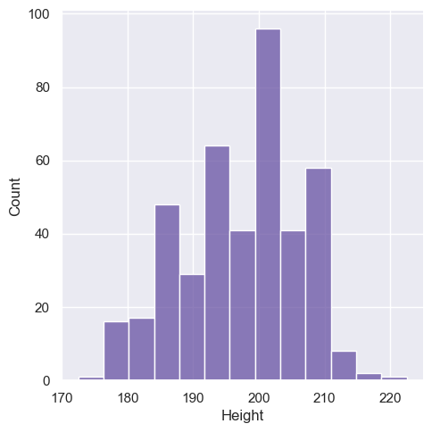

```r
# Python
sns.displot(x = 'Height', data = nba_stats, color = my_color);
```

Как во всех командных играх, в баскетболе у каждого игрока есть своя роль и функции. Это определяется его позицией.  
Итак, в баскетболе существует 5 позиций:

1. PG - Point Guard (Разыгрывающий защитник)
2. SG - Shooting Guard (Атакующий защитник)
3. SF - Small Forward (Лёгкий форвард)
4. PF - Power Forward (Тяжёлый форвард)
5. C - Center (Центровой)

**Гипотеза**: Существует корреляция между ростом игрока и его позицией на площадке.  
Выделим подмножества данных на нашей гистограмме.

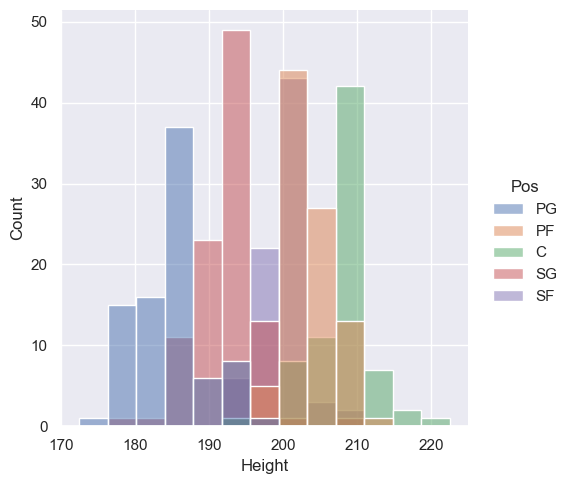

```r
# Python
sns.displot(x = 'Height', hue = 'Pos', data = nba_stats);
```

Для того, чтобы показать это более наглядно, отрисуем гистограммы по росту игроков на каждой из позиций отдельно.  
А также добавим линию, которая будет отражать характер распределения.

Для этого используется **метод ядерной оценки плотности**.

**Ядерная оценка плотности (Kernel Density Estimation, KDE)** — это непараметрический способ оценки плотности случайной величины. Ядерная оценка плотности является задачей сглаживания данных, когда делается заключение о совокупности, основываясь на конечных выборках данных.

Данный метод уже реализован в библиотечной функции `displot`, необходимо просто включить параметр `kde` в аргументах функции. Но каков его принцип работы?

1. Сначала для каждой точки наблюдений строится график нормального распределения с центром в этой точке.
2. Значения каждой нормальной кривой суммируются, а затем полученное значение нормализуется так, чтобы площадь под результирующей кривой стала равна 1.
3. Полученный график сглаживается в зависимости от выбора **полосы пропускания**.

**Полоса пропускания ядра** является свободным параметром, который оказывает сильное влияние на результат оценки.  
Здесь я использую ту пропускную способность, которую предложил `matplotlib` на основе моих данных, считая такое значение наиболее оптимальным.

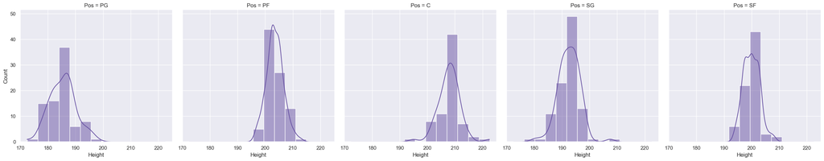

```r
# Python
sns.displot(x = 'Height', col = 'Pos', kde = True, data = nba_stats, color = my_color);
```

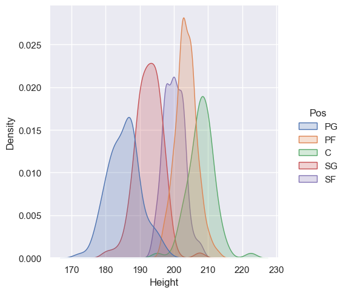

```r
# Python
sns.displot(x = "Height",
            hue = "Pos",
            kind = "kde",
            fill = True,
            data = nba_stats);
```

Таким образом, мы убедились в том, что рост игроков распределён в соответсвии с их позициями, тем самым подтвердив гипотезу наглядно.  
Действительно, более низкие игроки обычно играют на позиции PG - Point Guard (Разыгрывающий), потому что обладают большой скоростью и манёвренностью.  
Высокие же игроки играют на позиции C - Center (Центровой), потому что пользуясь преимуществами своего роста и комплекции, они могут легко зарабатывать очки под кольцом и отлично защищаться.

Посмотрим гистограмму с ядерными оценками в R:

```r
# R
# фильтруем таблицу
nba_stats_pg <- filter_data(nba_stats, 'Pos', 'PG')
nba_stats_pg # игроки на позиции Point Guard

data <- nba_stats_pg$Heigh # будем смотреть распределение роста
```

A data.frame: 84 × 34

| Name <chr> | Games.Played <int> | MIN <int> | PTS <int> | FGM <int> | FGA <int> | FG. <dbl> | X3PM <int> | X3PA <int> | X3P. <dbl> | ⋯ | Age <int> | Birth_Place <chr> | Birthdate <chr> | Collage <chr> | Experience <chr> | Height <dbl> | Pos <chr> | Team <chr> | Weight <dbl> | BMI <dbl> |
| --- | --- | --- | --- | --- | --- | --- | --- | --- | --- | --- | --- | --- | --- | --- | --- | --- | --- | --- | --- | --- |
| AJ Price | 26 | 324 | 133 | 51 | 137 | 37.2 | 15 | 57 | 26.3 | ⋯ | 29 | us | October 7, 1986 | University of Connecticut | 5 | 185.0 | PG | PHO | 81.45 | 23.79839 |
| Aaron Brooks | 82 | 1885 | 954 | 344 | 817 | 42.1 | 121 | 313 | 38.7 | ⋯ | 30 | us | January 14, 1985 | University of Oregon | 6 | 180.0 | PG | CHI | 72.45 | 22.36111 |
| Andre Miller | 81 | 1253 | 355 | 145 | 290 | 50.0 | 7 | 34 | 20.6 | ⋯ | 39 | us | March 19, 1976 | University of Utah | 15 | 187.5 | PG | WAS | 90.00 | 25.60000 |
| Brandon Jennings | 41 | 1173 | 632 | 218 | 543 | 40.1 | 76 | 211 | 36.0 | ⋯ | 26 | us | September 23, 1989 |  | 5 | 182.5 | PG | DET | 76.50 | 22.96866 |
| Brian Roberts | 72 | 1330 | 480 | 176 | 452 | 38.9 | 62 | 193 | 32.1 | ⋯ | 30 | us | December 3, 1985 | University of Dayton | 2 | 182.5 | PG | CHA | 77.85 | 23.37399 |
| Bryce Cotton | 15 | 159 | 80 | 29 | 69 | 42.0 | 7 | 20 | 35.0 | ⋯ | 23 | us | August 11, 1992 | Providence College | R | 182.5 | PG | UTA | 74.25 | 22.29311 |
| C.J. Watson | 57 | 1422 | 570 | 181 | 417 | 43.4 | 70 | 175 | 40.0 | ⋯ | 31 | us | April 17, 1984 | University of Tennessee | 7 | 185.0 | PG | IND | 78.75 | 23.00950 |
| Chris Paul | 82 | 2857 | 1564 | 568 | 1170 | 48.5 | 139 | 349 | 39.8 | ⋯ | 30 | us | May 6, 1985 | Wake Forest University | 9 | 180.0 | PG | LAC | 78.75 | 24.30556 |
| Cory Joseph | 79 | 1444 | 535 | 207 | 411 | 50.4 | 16 | 44 | 36.4 | ⋯ | 24 | ca | August 20, 1991 | University of Texas at Austin | 3 | 187.5 | PG | SAS | 86.85 | 24.70400 |
| D.J. Augustin | 82 | 1964 | 777 | 258 | 647 | 39.9 | 83 | 246 | 33.7 | ⋯ | 28 | us | November 10, 1987 | University of Texas at Austin | 6 | 180.0 | PG | OKC | 82.35 | 25.41667 |
| Damian Lillard | 82 | 2925 | 1720 | 590 | 1360 | 43.4 | 196 | 572 | 34.3 | ⋯ | 25 | us | July 15, 1990 | Weber State University | 2 | 187.5 | PG | POR | 87.75 | 24.96000 |
| Dante Exum | 82 | 1817 | 393 | 145 | 416 | 34.9 | 83 | 264 | 31.4 | ⋯ | 20 | au | July 13, 1995 |  | R | 195.0 | PG | UTA | 85.50 | 22.48521 |
| Darius Morris | 38 | 299 | 83 | 36 | 106 | 34.0 | 7 | 33 | 21.2 | ⋯ | 24 | us | January 3, 1991 | University of Michigan | 3 | 190.0 | PG | NJN | 85.50 | 23.68421 |
| Darren Collison | 45 | 1565 | 725 | 260 | 550 | 47.3 | 60 | 161 | 37.3 | ⋯ | 28 | us | August 23, 1987 | University of California, Los Angeles | 5 | 180.0 | PG | SAC | 78.75 | 24.30556 |
| David Stockton | 3 | 33 | 8 | 2 | 6 | 33.3 | 1 | 2 | 50.0 | ⋯ | 24 | us | June 24, 1991 | Gonzaga University | R | 177.5 | PG | SAC | 74.25 | 23.56675 |
| Dennis Schroder | 77 | 1516 | 768 | 284 | 665 | 42.7 | 52 | 148 | 35.1 | ⋯ | 22 | de | September 15, 1993 |  | 1 | 182.5 | PG | ATL | 77.40 | 23.23888 |
| Derrick Rose | 51 | 1530 | 904 | 338 | 835 | 40.5 | 76 | 271 | 28.0 | ⋯ | 27 | us | October 4, 1988 | University of Memphis | 5 | 187.5 | PG | CHI | 85.50 | 24.32000 |
| Devin Harris | 76 | 1685 | 665 | 219 | 524 | 41.8 | 95 | 266 | 35.7 | ⋯ | 32 | us | February 27, 1983 | University of Wisconsin | 10 | 187.5 | PG | DAL | 86.40 | 24.57600 |
| Donald Sloan | 53 | 1107 | 391 | 145 | 355 | 40.8 | 41 | 131 | 31.3 | ⋯ | 27 | us | January 15, 1988 | Texas A&M University | 3 | 187.5 | PG | IND | 92.25 | 26.24000 |
| Dwight Buycks | 6 | 123 | 52 | 18 | 40 | 45.0 | 7 | 11 | 63.6 | ⋯ | 26 | us | March 6, 1989 | Marquette University | 1 | 187.5 | PG | LAL | 85.50 | 24.32000 |
| Elfrid Payton | 82 | 2489 | 731 | 301 | 708 | 42.5 | 11 | 42 | 26.2 | ⋯ | 21 | us | February 22, 1994 | University of Louisiana at Lafayette | R | 190.0 | PG | ORL | 83.25 | 23.06094 |
| Eric Bledsoe | 81 | 2800 | 1377 | 468 | 1046 | 44.7 | 88 | 272 | 32.4 | ⋯ | 26 | us | December 9, 1989 | University of Kentucky | 4 | 182.5 | PG | PHO | 85.50 | 25.67086 |
| Erick Green | 43 | 410 | 146 | 61 | 162 | 37.7 | 14 | 47 | 29.8 | ⋯ | 24 | us | May 9, 1991 | Virginia Polytechnic Institute and State University | R | 190.0 | PG | DEN | 83.25 | 23.06094 |
| Gal Mekel | 4 | 43 | 6 | 3 | 20 | 15.0 | 0 | 3 | 0.0 | ⋯ | 27 | il | March 4, 1988 | Wichita State University | 1 | 187.5 | PG | NOH | 85.95 | 24.44800 |
| George Hill | 43 | 1267 | 692 | 255 | 535 | 47.7 | 69 | 193 | 35.8 | ⋯ | 29 | us | May 4, 1986 | Indiana University-Purdue University Indianapolis | 6 | 187.5 | PG | IND | 84.60 | 24.06400 |
| Greivis Vasquez | 82 | 1991 | 775 | 296 | 725 | 40.8 | 133 | 351 | 37.9 | ⋯ | 28 | ve | January 16, 1987 | University of Maryland | 4 | 195.0 | PG | TOR | 97.65 | 25.68047 |
| Isaiah Canaan | 47 | 938 | 432 | 146 | 378 | 38.6 | 91 | 246 | 37.0 | ⋯ | 24 | us | May 21, 1991 | Murray State University | 1 | 180.0 | PG | PHI | 90.45 | 27.91667 |
| Isaiah Thomas | 67 | 1726 | 1101 | 335 | 796 | 42.1 | 129 | 346 | 37.3 | ⋯ | 26 | us | February 7, 1989 | University of Washington | 3 | 172.5 | PG | BOS | 83.25 | 27.97732 |
| J.J. Barea | 77 | 1362 | 580 | 225 | 536 | 42.0 | 54 | 167 | 32.3 | ⋯ | 31 | pr | June 26, 1984 | Northeastern University | 8 | 180.0 | PG | DAL | 83.25 | 25.69444 |
| Jameer Nelson | 63 | 1406 | 523 | 205 | 504 | 40.7 | 89 | 258 | 34.5 | ⋯ | 33 | us | February 9, 1982 | Saint Joseph's University | 10 | 180.0 | PG | DAL | 85.50 | 26.38889 |
| ⋮ | ⋮ | ⋮ | ⋮ | ⋮ | ⋮ | ⋮ | ⋮ | ⋮ | ⋮ | ⋱ | ⋮ | ⋮ | ⋮ | ⋮ | ⋮ | ⋮ | ⋮ | ⋮ | ⋮ | ⋮ |
| Michael Carter-Williams | 66 | 2150 | 966 | 364 | 919 | 39.6 | 36 | 153 | 23.5 | ⋯ | 24 | us | October 10, 1991 | Syracuse University | 1 | 195.0 | PG | PHI | 85.50 | 22.48521 |
| Mike Conley | 70 | 2225 | 1107 | 393 | 882 | 44.6 | 107 | 277 | 38.6 | ⋯ | 28 | us | October 11, 1987 | Ohio State University | 7 | 182.5 | PG | MEM | 78.75 | 23.64421 |
| Mo Williams | 68 | 1980 | 964 | 341 | 860 | 39.7 | 119 | 348 | 34.2 | ⋯ | 33 | us | December 19, 1982 | University of Alabama | 11 | 182.5 | PG | CHA | 89.10 | 26.75174 |
| Norris Cole | 75 | 1831 | 573 | 230 | 558 | 41.2 | 55 | 176 | 31.3 | ⋯ | 27 | us | October 13, 1988 | Cleveland State University | 3 | 185.0 | PG | NOH | 78.75 | 23.00950 |
| Pablo Prigioni | 67 | 1197 | 274 | 91 | 228 | 39.9 | 57 | 166 | 34.3 | ⋯ | 38 | ar | May 17, 1977 |  | 2 | 187.5 | PG | NYK | 83.25 | 23.68000 |
| Patrick Beverley | 56 | 1727 | 568 | 204 | 532 | 38.3 | 115 | 323 | 35.6 | ⋯ | 27 | us | July 12, 1988 | University of Arkansas | 2 | 182.5 | PG | HOU | 83.25 | 24.99531 |
| Patty Mills | 51 | 801 | 351 | 128 | 336 | 38.1 | 62 | 182 | 34.1 | ⋯ | 27 | au | August 11, 1988 | Saint Mary's College of California | 5 | 180.0 | PG | SAS | 83.25 | 25.69444 |
| Phil Pressey | 50 | 600 | 177 | 64 | 174 | 36.8 | 16 | 65 | 24.6 | ⋯ | 24 | us | February 17, 1991 | University of Missouri | 1 | 177.5 | PG | BOS | 78.75 | 24.99504 |
| Rajon Rondo | 68 | 2019 | 608 | 275 | 645 | 42.6 | 27 | 86 | 31.4 | ⋯ | 29 | us | February 22, 1986 | University of Kentucky | 8 | 182.5 | PG | DAL | 83.70 | 25.13042 |
| Ramon Sessions | 64 | 1188 | 402 | 125 | 334 | 37.4 | 19 | 60 | 31.7 | ⋯ | 29 | us | April 11, 1986 | University of Nevada, Reno | 7 | 187.5 | PG | WAS | 85.50 | 24.32000 |
| Ray McCallum | 68 | 1436 | 503 | 206 | 470 | 43.8 | 34 | 111 | 30.6 | ⋯ | 24 | us | June 12, 1991 | University of Detroit Mercy | 1 | 187.5 | PG | SAC | 85.50 | 24.32000 |
| Raymond Felton | 29 | 281 | 108 | 43 | 106 | 40.6 | 10 | 34 | 29.4 | ⋯ | 31 | us | June 26, 1984 | University of North Carolina | 9 | 182.5 | PG | DAL | 92.25 | 27.69750 |
| Reggie Jackson | 77 | 2268 | 1117 | 432 | 996 | 43.4 | 72 | 241 | 29.9 | ⋯ | 25 | it | April 16, 1990 | Boston College | 3 | 187.5 | PG | OKC | 93.60 | 26.62400 |
| Rodney Stuckey | 71 | 1874 | 896 | 332 | 754 | 44.0 | 55 | 141 | 39.0 | ⋯ | 29 | us | April 21, 1986 | Eastern Washington University | 7 | 192.5 | PG | IND | 94.50 | 25.50177 |
| Ronnie Price | 43 | 982 | 221 | 77 | 223 | 34.5 | 31 | 109 | 28.4 | ⋯ | 32 | us | June 21, 1983 | Utah Valley State College | 9 | 185.0 | PG | LAL | 85.50 | 24.98174 |
| Russ Smith | 12 | 65 | 30 | 8 | 25 | 32.0 | 2 | 11 | 18.2 | ⋯ | 24 | us | April 19, 1991 | University of Louisville | R | 180.0 | PG | MEM | 74.25 | 22.91667 |
| Seth Curry | 2 | 8 | 0 | 0 | 3 | 0.0 | 0 | 1 | 0.0 | ⋯ | 25 | us | August 23, 1990 | Duke University | 1 | 185.0 | PG | PHO | 83.25 | 24.32432 |
| Shane Larkin | 76 | 1865 | 470 | 187 | 432 | 43.3 | 35 | 116 | 30.2 | ⋯ | 23 | us | October 2, 1992 | University of Miami | 1 | 177.5 | PG | NYK | 78.75 | 24.99504 |
| Shaun Livingston | 78 | 1468 | 461 | 198 | 396 | 50.0 | 0 | 2 | 0.0 | ⋯ | 30 | us | September 11, 1985 |  | 9 | 197.5 | PG | GSW | 86.40 | 22.15030 |
| Shelvin Mack | 55 | 833 | 299 | 117 | 292 | 40.1 | 40 | 127 | 31.5 | ⋯ | 25 | us | April 22, 1990 | Butler University | 3 | 187.5 | PG | ATL | 91.35 | 25.98400 |
| Spencer Dinwiddie | 34 | 455 | 145 | 51 | 169 | 30.2 | 12 | 65 | 18.5 | ⋯ | 22 | us | April 6, 1993 | University of Colorado | R | 195.0 | PG | DET | 90.00 | 23.66864 |
| Stephen Curry | 80 | 2613 | 1900 | 653 | 1341 | 48.7 | 286 | 646 | 44.3 | ⋯ | 27 | us | March 14, 1988 | Davidson College | 5 | 187.5 | PG | GSW | 85.50 | 24.32000 |
| Steve Blake | 81 | 1529 | 350 | 122 | 327 | 37.3 | 77 | 219 | 35.2 | ⋯ | 35 | us | February 26, 1980 | University of Maryland | 11 | 187.5 | PG | POR | 77.40 | 22.01600 |
| Tim Frazier | 11 | 240 | 57 | 21 | 61 | 34.4 | 5 | 17 | 29.4 | ⋯ | 25 | us | November 1, 1990 | Pennsylvania State University | R | 182.5 | PG | POR | 76.50 | 22.96866 |
| Tony Parker | 68 | 1953 | 976 | 404 | 832 | 48.6 | 38 | 89 | 42.7 | ⋯ | 33 | be | May 17, 1982 |  | 13 | 185.0 | PG | SAS | 83.25 | 24.32432 |
| Trey Burke | 76 | 2288 | 973 | 370 | 1005 | 36.8 | 124 | 390 | 31.8 | ⋯ | 23 | us | November 12, 1992 | University of Michigan | 1 | 182.5 | PG | UTA | 85.95 | 25.80597 |
| Ty Lawson | 75 | 2665 | 1143 | 404 | 926 | 43.6 | 70 | 205 | 34.1 | ⋯ | 28 | us | November 3, 1987 | University of North Carolina | 5 | 177.5 | PG | DEN | 87.75 | 27.85162 |
| Tyler Ennis | 33 | 411 | 121 | 52 | 144 | 36.1 | 12 | 43 | 27.9 | ⋯ | 21 | ca | August 24, 1994 | Syracuse University | R | 187.5 | PG | PHO | 87.30 | 24.83200 |
| Will Cherry | 8 | 69 | 15 | 5 | 19 | 26.3 | 2 | 9 | 22.2 | ⋯ | 24 | us | February 8, 1991 | University of Montana | R | 180.0 | PG | CLE | 83.25 | 25.69444 |
| Zach LaVine | 77 | 1902 | 778 | 286 | 677 | 42.2 | 57 | 167 | 34.1 | ⋯ | 20 | us | March 10, 1995 | University of California, Los Angeles | R | 192.5 | PG | MIN | 85.05 | 22.95159 |

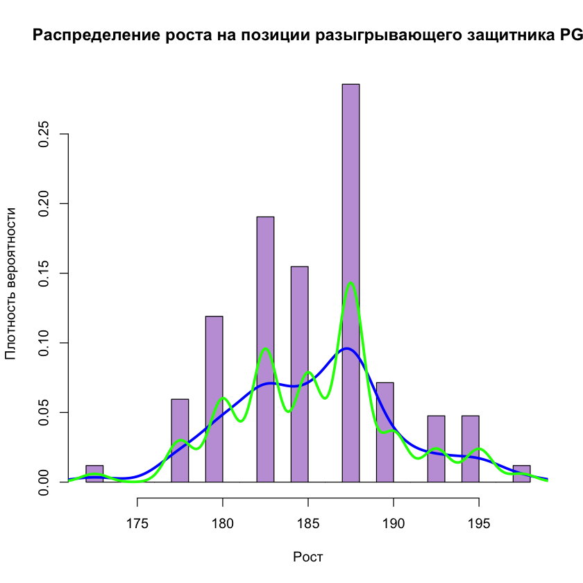

```r
# R
# Строим гистограмму и ядерные оценки
hist(data, breaks = 20, freq = FALSE, col = rgb(0.5, 0.2, 0.7, 0.5),
     xlab = "Рост",
     ylab = "Плотность вероятности",
     main = "Распределение роста на позиции разыгрывающего защитника PG")
lines(density(data), col = "blue", lwd = 3)
lines(density(data, bw = 0.8), col = "green", lwd = 3)
```

Вообще, позиция игрока являеется очень хорошей качественной переменной (фактором), потому что позволяет отследить много зависимостей. Поэтому в последующих заданиях будет часто использоваться.

## 2. Анализ данных с помощью cdplot, dotchart, boxplot, stripchart.

**cdplot:**

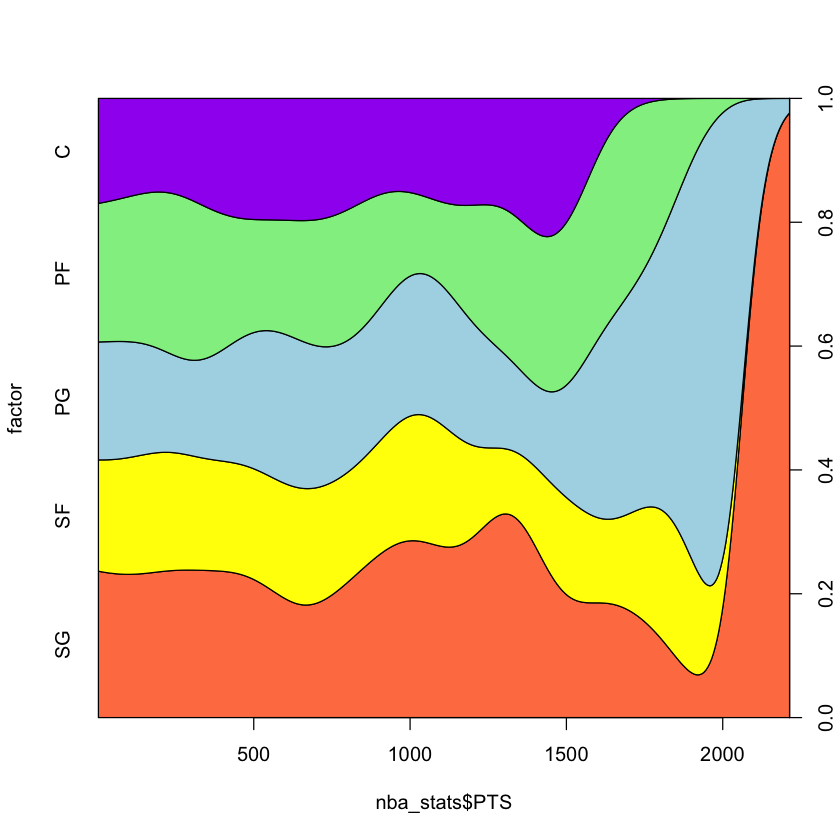

```r
# R
# Распределние по количеству очков у игроков разных позиций

nba_stats$factor <- factor(nba_stats$Pos)

cdplot(factor ~ nba_stats$PTS, col = c("coral", "yellow", "lightblue", "lightgreen", "purple"), data = nba_stats)
```

Для визуализации связи между двумя переменными, одна из которых является количественной, а другая качественной (фактором), можно использовать диаграмму размахов. Если зависимой является качественная переменная, то удобно воспользоваться одной из базовых графических функций R - `cdplot()`, позволяющей совмещать на одном графике плотности вероятности для каждого уровня интересующей исследователя качественной переменной (англ. conditional density plot).

Аналогом этой функции в Python служит всё та же функция `displot()` из библиотеки `seaborn`, которую мы уже использовали ранее при работе с ядерными оценками. Теперь же добавляем параметр `multiple = "fill"`, чтобы видеть график именно в том виде, который строит `cdplot()`.

Давайте посмотрим на то, игроки каких позиций больше очков приносят команде. Для этого обратимся к таблице `NBA SEASONS` и рассмотрим игры за 2017 год.  
На графике отражаю распределение по количеству набранных очков игроками с разных позиций.

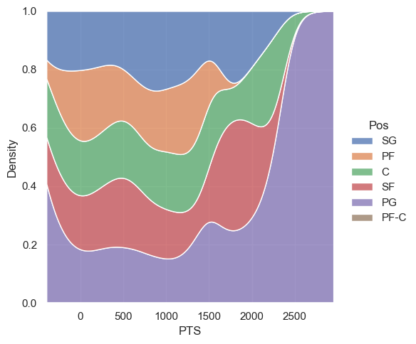

```r
# Python
sns.displot(data = nba_seasons[nba_seasons['Year']==2017], hue = "Pos", multiple = "fill", x = "PTS", kind = "kde");
```

**dotchart:**

**Точечный график** как представление распределения состоит из группы точек данных, нанесенных на простой масштаб. Точечные диаграммы используются для непрерывных , количественных , одномерных данных. Точечные графики - это один из простейших статистических графиков, который подходит для небольших и средних наборов данных. Они полезны для выделения кластеров и пробелов, а также выбросов . Другое их преимущество - сохранение числовой информации. При работе с большими наборами данных (около 20–30 или более точек данных) связанный стержневой график , прямоугольная диаграмма или гистограмма могут быть более эффективными, так как точечные графики после этого момента могут стать слишком загроможденными. Точечные графики можно отличить от гистограмм тем, что точки не расположены равномерно по горизонтальной оси.

Хотя сюжет кажется простым, его расчет и лежащая в его основе статистическая теория непросты. Алгоритм вычисления точечной диаграммы тесно связан с оценкой плотности ядра . Выбранный размер точек влияет на внешний вид сюжета. Выбор размера точки эквивалентен выбору полосы пропускания для оценки плотности ядра.

В R это реализуется с помощью функции `dotchart()`, в Python аналогичный график строится при помощи функции `scatter()`.

Итак, нам нужно небольшое количество данных. Рассмотрим игровые показатели команды Golden State Warriors (GSW) за игровой сезон 2017 года и отметим на точечном графике количество реализованных двухочковых бросков (2P) у различных игроков.

```r
# Python
gsw_2017 = nba_seasons[nba_seasons['Year']==2017][nba_seasons['Tm']=='GSW']
import plotly.express as px
fig = px.scatter(gsw_2017, y = "Player", x = "2P", height=600, color = "Pos")
fig.update_yaxes(type='category', tickvals=gsw_2017['Player'].tolist())
fig.show()
```

[output not shown]

**boxtplot:**

**Диаграммы размаха («ящик с усами») (Box and Whisker Plot или Box Plot)** – это удобный способ визуального представления групп числовых данных через квартили.

Прямые линии, исходящие из ящика, называются «усами» и используются для обозначения степени разброса (дисперсии) за пределами верхнего и нижнего квартилей. Выбросы иногда отображаются в виде отдельных точек, находящихся на одной линии с усами. Диаграммы размаха могут располагаться как горизонтально, так и вертикально.

Диаграммы размаха, как правило, используются в описательной статистике и позволяют быстро исследовать один или более наборов данных в графическом виде. Несмотря на то, что в сравнении с гистограммой или графиком плотности, этот график может показаться примитивным, его преимущество – в экономии пространства, что особенно удобно при сравнении распределений между большим количеством групп или наборов данных.

Виды наблюдений, которые можно сделать на основе ящика с усами:

- Каковы ключевые значения, например: средний показатель, медиана 25го перцентиля и так далее.
- Существуют ли выбросы и каковы их значения.
- Cимметричны ли данные.
- Насколько плотно сгруппированы данные.
- Смещены ли данные и, если да, то в каком направлении.

[figure not shown]

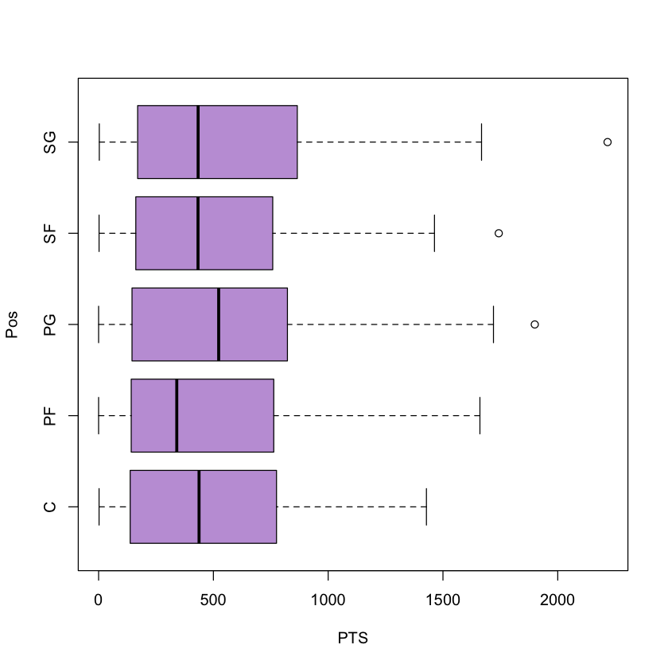

```r
# R
boxplot(PTS ~ Pos,
        col = rgb(0.5, 0.2, 0.7, 0.5),
        data = nba_stats, horizontal=TRUE)
```

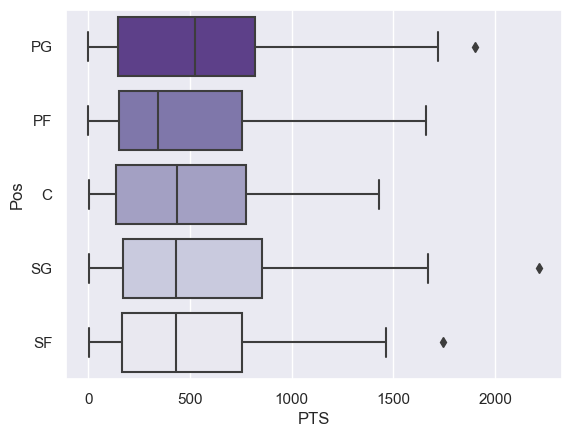

```r
# Python
sns.boxplot(data = nba_stats, y = "Pos", x = "PTS", palette="Purples_r");
```

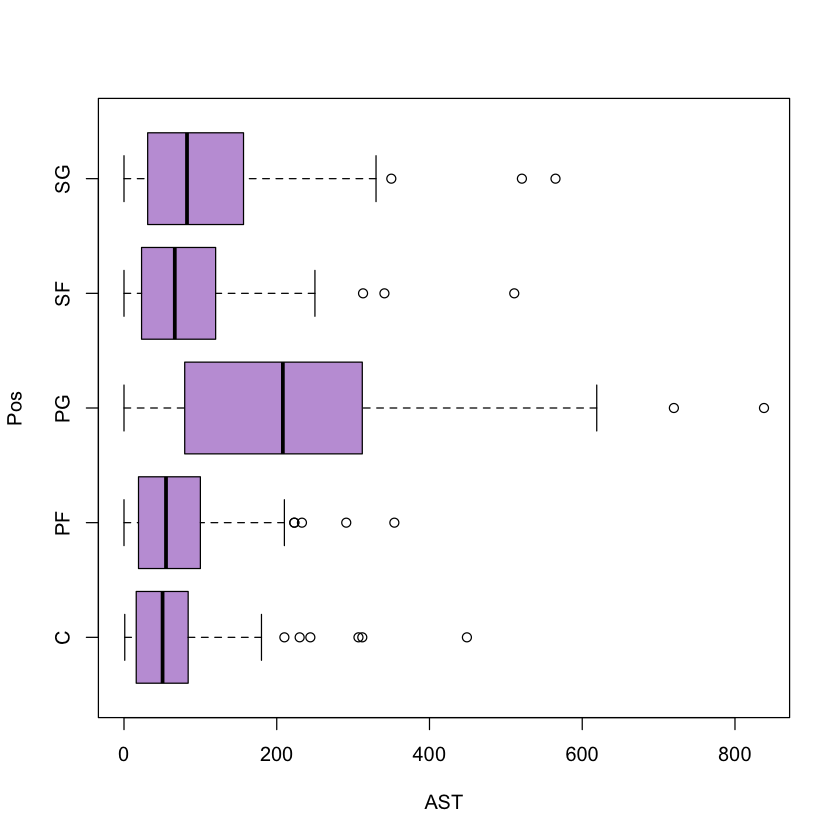

```r
# R
boxplot(AST ~ Pos,
        col = rgb(0.5, 0.2, 0.7, 0.5),
        data = nba_stats, horizontal=TRUE)
```

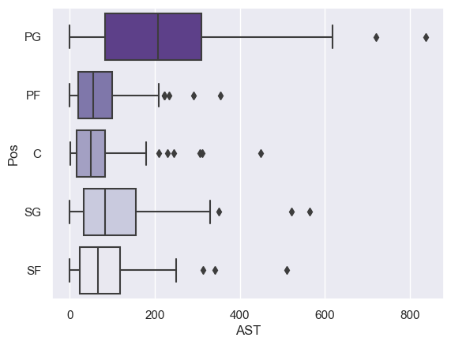

```r
# Python
sns.boxplot(data = nba_stats, y = "Pos", x = "AST", palette="Purples_r");
```

На данном графике рассмотрели количество результативных передач (Assists). У разыгрывающих их принципиально больше: больше медианное значение и сам размах в целом шире. Игроки других позиций пасуют сильно меньше.

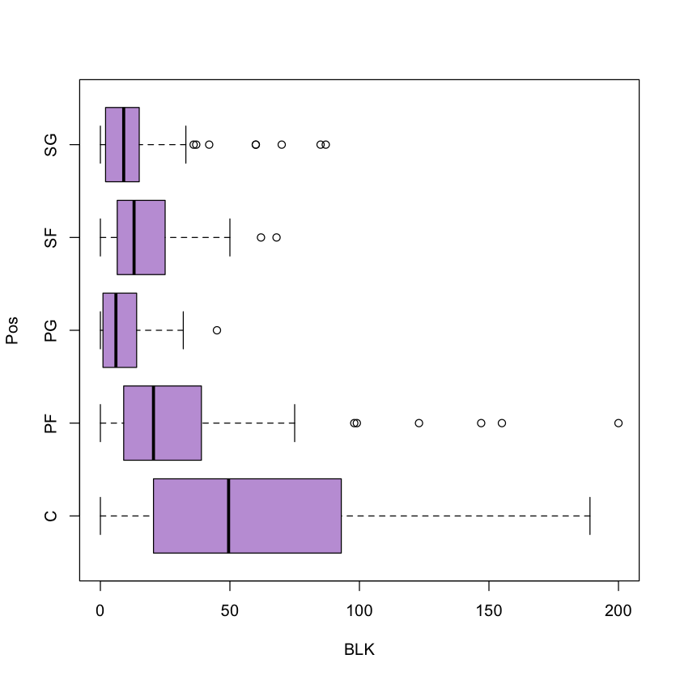

```r
# R
boxplot(BLK ~ Pos,
        col = rgb(0.5, 0.2, 0.7, 0.5),
        data = nba_stats, horizontal=TRUE)
```

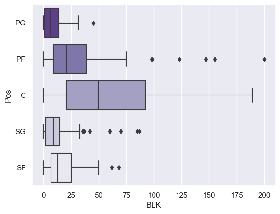

```r
# Python
sns.boxplot(data = nba_stats, y = "Pos", x = "BLK", palette="Purples_r");
```

На этом графике рассмотрим действия игроков в защите - блокшот, то есть ситуация, когда игрок блокирует бросок соперника.  
Легко заметить, что центровые игроки выделяются. Блогадаря высокому росту и габаритам, этот приём даётся им лучше всего и они активно его практикуют.  
Выбросы тоже случаются, но всё же общая картина даёт понять, что центровые игроки занимают лидирующие места по этому показателю.

**stripchart:**

В языке R функция `stripchart()` отвечает за построение одномерных диаграмм рассеяния. **Диаграмма рассеяния** показывает взаимосвязь между двумя числовыми признаками с помощью точек, показывающих движение этих переменных вместе.  
В языке Python такую диаграмму мы можем реализовать с помощью функции `stripplot()`.

На данном графике я отразила количество успешных трёхочковых бросков (каждая отдельная точка - сумма по всем игрокам за сезон) c течением времени.

Окунёмся в историю: раньше в баскетболе не практиковались броски с дальних дистанций. Со временем стиль игры менялся и пришла идея ввести трёхочковый бросок в игру. В профессиональный баскетбол трёхочковый бросок проник только в начале 1960-х годов, впервые появившись в 1961 году в правилах Американской баскетбольной лиги. Наконец, в сезоне 1979/80 правило о трёхочковых бросках было принято и в НБА.

```r
# Python
nba_3pt = pd.read_csv("/Users/mazur/Desktop/PRAK_5sem/nba/3pt.csv") # вспомогательная таблица, где просто записана сумма количества трёхочковых бросков за каждый год
```

```
Using categorical units to plot a list of strings that are all parsable as floats or dates. If these strings should be plotted as numbers, cast to the appropriate data type before plotting.
```

```
Using categorical units to plot a list of strings that are all parsable as floats or dates. If these strings should be plotted as numbers, cast to the appropriate data type before plotting.
```

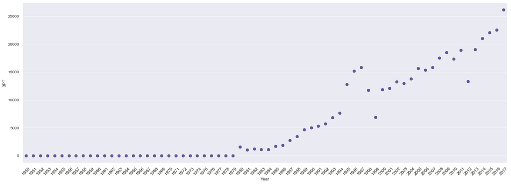

```r
# Python
fig, ax = plt.subplots(figsize=(24, 8), dpi=80)
sns.stripplot(nba_3pt, y = '3PT', x = "Year", jitter=0.45, size=8, linewidth=0.5, color="#6852A3")
plt.tick_params(axis='x', which='major', labelsize=12, rotation=45)

plt.show()
```

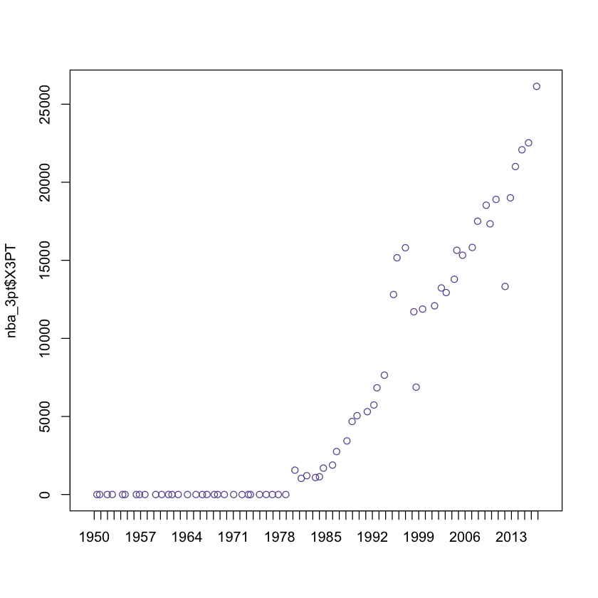

```r
# R
nba_3pt <- read.csv(file = "/Users/mazur/Desktop/PRAK_5sem/nba/3pt.csv", header = TRUE)
nba_3pt <- na.omit(nba_3pt)

stripchart(nba_3pt$X3PT ~ nba_3pt$Year,
           method = "jitter",
           jitter = 0.45,
           pch = 1, col = '#6852A3', vertical = TRUE)
```

## Проверка, являются ли наблюдения выбросами с точки зрения формальных статистических критериев Граббса и Q-теста Диксона. Визуализация результатов.

**Тесты Граббса и Диксона** используется для определения наличия выбросов в наборе данных.  
Предлагаю посмотреть, у кого из игроков рекордные показатели по количеству успешно-реализованных трёхочковых бросков таким образом.

**Тест Граббса**

```r
# Python
import smirnov_grubbs as grubbs

#perform Grubbs' test to see if minimum value is an outlier
grubbs. max_test_indices (nba_stats['3PM'], alpha=.05)
```

```
[433, 281]
```

Тест Граббса нашел 2 выброса: 433 запись и 281 запись в моей таблице. Посмотрим, что за игрок находится под 433 индексом в таблице:

```r
# Python
print(nba_stats.at[433, 'Name'])
```

```
Stephen Curry
```

Теперь проведём тест Граббса с помощью языка R:

```r
# R
data <- nba_stats$X3PM[1:500]
grubbs.test(data)
```

```
	Grubbs test for one outlier

data:  data
G = 4.94697, U = 0.94173, p-value = 0.0001099
alternative hypothesis: highest value 286 is an outlier
```

Тест Граббса сообщает, что значение выброса = 286. Давайте посмотрим, у какого игрока такое значение в соответсвующем столбце.

```r
nba_stats$Name[nba_stats$X3PM == 286]
```

'Stephen Curry'

**Тест Диксона**

**Примечание:** Тест Диксона реализован в качестве функции только на языке R. Поэтому решение на языке Python для этого пункта не приводится.

Для теста Диксона существуют ограничение - он может обрабатывать только 30 записей. Поэтому искуственно "подскажем" алгоритму, где именно стоит искать выброс. В этой таблице Stephen Curry находится на 374 строке, поэтому укажу такой интервал, где он точно будет.

```r
# R
data <- nba_stats$X3PM[370:390]
dixon.test(data)
```

```
	Dixon test for outliers

data:  data
Q = 0.57692, p-value = 0.0003989
alternative hypothesis: highest value 286 is an outlier
```

Тест Диксона также сообщает, что выбросное значение = 286. А это игрок Stephen Curry.

Здесь мы посмотрели тесты Граббса и Диксона для максимального значения по количеству реализованных трёхочковых бросков. Выбросом оказался игрок Стефен Карри, который действительно является рекордсменом по числу дальних бросков.

## Инструменты для заполнения пропусков в данных. Сравнение результатов заполнения с истинными значениями.

В одном из предыдущих заданий мы убедились в том, что существует тенденция роста дальних бросков. И она практические линейная.  
Поэтому в этом задании я хочу поработать с этими данными. Для этого возьмём последние 37 содержательных строк таблицы.

```r
# Python
df = nba_3pt.tail(37)
df
```

|  | Year | 3PT |
| --- | --- | --- |
| 31 | 1981 | 1035.0 |
| 32 | 1982 | 1206.0 |
| 33 | 1983 | 1091.0 |
| 34 | 1984 | 1139.0 |
| 35 | 1985 | 1692.0 |
| 36 | 1986 | 1886.0 |
| 37 | 1987 | 2753.0 |
| 38 | 1988 | 3433.0 |
| 39 | 1989 | 4678.0 |
| 40 | 1990 | 5050.0 |
| 41 | 1991 | 5307.0 |
| 42 | 1992 | 5736.0 |
| 43 | 1993 | 6836.0 |
| 44 | 1994 | 7646.0 |
| 45 | 1995 | 12809.0 |
| 46 | 1996 | 15163.0 |
| 47 | 1997 | 15806.0 |
| 48 | 1998 | 11706.0 |
| 49 | 1999 | 6874.0 |
| 50 | 2000 | 11878.0 |
| 51 | 2001 | 12087.0 |
| 52 | 2002 | 13230.0 |
| 53 | 2003 | 12933.0 |
| 54 | 2004 | 13789.0 |
| 55 | 2005 | 15643.0 |
| 56 | 2006 | 15325.0 |
| 57 | 2007 | 15825.0 |
| 58 | 2008 | 17504.0 |
| 59 | 2009 | 18529.0 |
| 60 | 2010 | 17336.0 |
| 61 | 2011 | 18902.0 |
| 62 | 2012 | 13325.0 |
| 63 | 2013 | 19002.0 |
| 64 | 2014 | 21004.0 |
| 65 | 2015 | 22080.0 |
| 66 | 2016 | 22525.0 |
| 67 | 2017 | 26140.0 |

```r
# Python
print(df['Year'][36], ',', df['3PT'][36])
print(df['Year'][42], ',', df['3PT'][42])
print(df['Year'][51], ',', df['3PT'][51])
print(df['Year'][65], ',', df['3PT'][65])
```

```
1986 , 1886.0
1992 , 5736.0
2001 , 12087.0
2015 , 22080.0
```

```
Using categorical units to plot a list of strings that are all parsable as floats or dates. If these strings should be plotted as numbers, cast to the appropriate data type before plotting.
```

```
Using categorical units to plot a list of strings that are all parsable as floats or dates. If these strings should be plotted as numbers, cast to the appropriate data type before plotting.
```

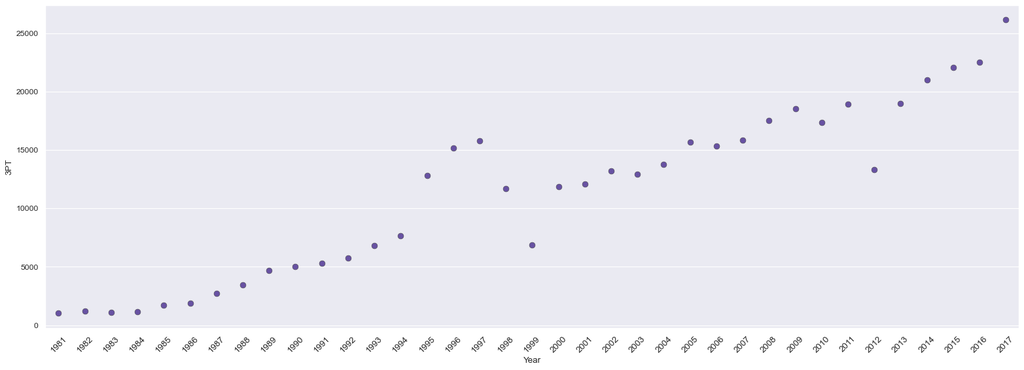

```r
# Python
fig, ax = plt.subplots(figsize=(24, 8), dpi=80)
sns.stripplot(df, y = '3PT', x = "Year", jitter=0.45, size=8, linewidth=0.5, color="#6852A3")
plt.tick_params(axis='x', which='major', labelsize=12, rotation=45)

plt.show()
```

Удалим некоторые строки.

```r
# Python
df['3PT'][36] = np.nan
df['3PT'][42] = np.nan
df['3PT'][51] = np.nan
df['3PT'][65] = np.nan

df['3PT'].isna().sum() # проверка на наличие пропусков
```

```
4
```

```
Using categorical units to plot a list of strings that are all parsable as floats or dates. If these strings should be plotted as numbers, cast to the appropriate data type before plotting.
```

```
Using categorical units to plot a list of strings that are all parsable as floats or dates. If these strings should be plotted as numbers, cast to the appropriate data type before plotting.
```

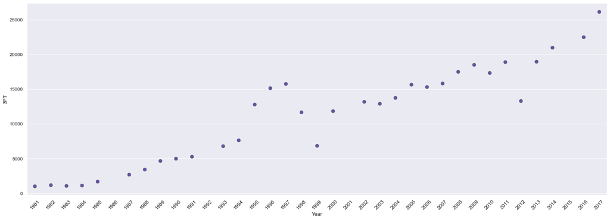

```r
# Python
fig, ax = plt.subplots(figsize=(24, 8), dpi=80)
sns.stripplot(df, y = '3PT', x = "Year", jitter=0.45, size=8, linewidth=0.5, color="#6852A3")
plt.tick_params(axis='x', which='major', labelsize=12, rotation=45)

plt.show()
```

В такой ситуации пропуски лучше заполнять средним по соседним двум значениям.

```r
# Python
df['3PT'][36] = (df['3PT'][35] + df['3PT'][37]) / 2
df['3PT'][42] = (df['3PT'][41] + df['3PT'][43]) / 2
df['3PT'][51] = (df['3PT'][50] + df['3PT'][52])/ 2
df['3PT'][65] = (df['3PT'][64] + df['3PT'][66]) / 2
```

```r
# Python
print(df['Year'][36], ',', df['3PT'][36])
print(df['Year'][42], ',', df['3PT'][42])
print(df['Year'][51], ',', df['3PT'][51])
print(df['Year'][65], ',', df['3PT'][65])
```

```
1986 , 2222.5
1992 , 6071.5
2001 , 12554.0
2015 , 21764.5
```

```
Using categorical units to plot a list of strings that are all parsable as floats or dates. If these strings should be plotted as numbers, cast to the appropriate data type before plotting.
```

```
Using categorical units to plot a list of strings that are all parsable as floats or dates. If these strings should be plotted as numbers, cast to the appropriate data type before plotting.
```

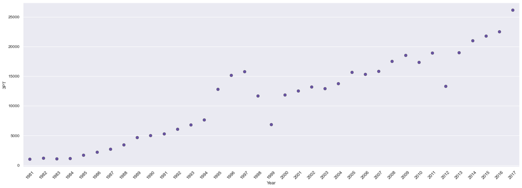

```r
# Python
fig, ax = plt.subplots(figsize=(24, 8), dpi=80)
sns.stripplot(df, y = '3PT', x = "Year", jitter=0.45, size=8, linewidth=0.5, color="#6852A3")
plt.tick_params(axis='x', which='major', labelsize=12, rotation=45)

plt.show()
```

Рассмотрим какое-нибудь распределение, похожее на нормальное. В первом задании мы работали с распределнием роста игроков на разных позициях. Воспользуемся этими данными.

```r
# Python
nba_stats_c = nba_stats[nba_stats['Pos']=='C']
nba_stats_c
```

|  | Name | Games Played | MIN | PTS | FGM | FGA | FG% | 3PM | 3PA | 3P% | ... | Age | Birth_Place | Birthdate | Collage | Experience | Height | Pos | Team | Weight | BMI |
| --- | --- | --- | --- | --- | --- | --- | --- | --- | --- | --- | --- | --- | --- | --- | --- | --- | --- | --- | --- | --- | --- |
| 4 | Al Horford | 76 | 2318 | 1156 | 519 | 965 | 53.8 | 11 | 36 | 30.6 | ... | 29.0 | do | June 3, 1986 | University of Florida | 7 | 205.0 | C | ATL | 110.25 | 26.234384 |
| 5 | Al Jefferson | 65 | 1992 | 1082 | 486 | 1010 | 48.1 | 2 | 5 | 40.0 | ... | 30.0 | us | January 4, 1985 | NaN | 10 | 205.0 | C | CHA | 130.05 | 30.945866 |
| 8 | Alex Kirk | 5 | 14 | 4 | 1 | 4 | 25.0 | 0 | 0 | 0.0 | ... | 24.0 | us | November 14, 1991 | University of New Mexico | R | 210.0 | C | CLE | 110.25 | 25.000000 |
| 9 | Alex Len | 69 | 1518 | 432 | 179 | 353 | 50.7 | 1 | 3 | 33.3 | ... | 22.0 | ua | June 16, 1993 | University of Maryland | 1 | 212.5 | C | PHO | 117.00 | 25.910035 |
| 11 | Alexis Ajinca | 68 | 957 | 443 | 181 | 329 | 55.0 | 0 | 0 | 0.0 | ... | 27.0 | fr | May 6, 1988 | NaN | 4 | 215.0 | C | NOH | 111.60 | 24.142780 |
| ... | ... | ... | ... | ... | ... | ... | ... | ... | ... | ... | ... | ... | ... | ... | ... | ... | ... | ... | ... | ... | ... |
| 445 | Tiago Splitter | 52 | 1030 | 428 | 169 | 303 | 55.8 | 0 | 0 | 0.0 | ... | 30.0 | br | January 1, 1985 | NaN | 4 | 207.5 | C | SAS | 110.25 | 25.606039 |
| 446 | Tim Duncan | 77 | 2227 | 1070 | 419 | 819 | 51.2 | 2 | 7 | 28.6 | ... | 39.0 | vi | April 25, 1976 | Wake Forest University | 17 | 207.5 | C | SAS | 112.50 | 26.128611 |
| 449 | Timofey Mozgov | 81 | 2046 | 785 | 314 | 566 | 55.5 | 2 | 6 | 33.3 | ... | 29.0 | ru | July 16, 1986 | NaN | 4 | 212.5 | C | CLE | 123.75 | 27.404844 |
| 471 | Tyson Chandler | 75 | 2286 | 771 | 293 | 440 | 66.6 | 0 | 0 | 0.0 | ... | 33.0 | us | October 2, 1982 | NaN | 13 | 212.5 | C | DAL | 108.00 | 23.916955 |
| 488 | Zaza Pachulia | 73 | 1730 | 606 | 240 | 529 | 45.4 | 0 | 3 | 0.0 | ... | 31.0 | ge | February 10, 1984 | NaN | 11 | 207.5 | C | MIL | 121.50 | 28.218900 |

72 rows × 34 columns

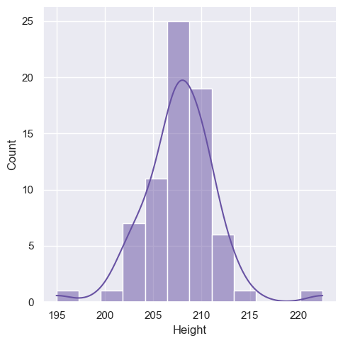

```r
# Python
sns.displot(x = 'Height', data = nba_stats_c, kde = True, color = my_color);
```

```r
# Python
print(nba_stats_c['Height'][446])
print(nba_stats_c['Height'][11])
print(nba_stats_c['Height'][8])
print(nba_stats_c['Height'][471])
```

```
207.5
215.0
210.0
212.5
```

```r
# Python
nba_stats_c['Height'][446] = np.nan
nba_stats_c['Height'][11] = np.nan
nba_stats_c['Height'][8] = np.nan
nba_stats_c['Height'][471] = np.nan


nba_stats_c['Height'].isna().sum() # проверка количества пропусков
```

```
4
```

```r
# Python
nba_stats_c['Height'][446] = nba_stats_c.mean()['Height']
nba_stats_c['Height'][11] = nba_stats_c.mean()['Height']
nba_stats_c['Height'][8] = nba_stats_c.mean()['Height']
nba_stats_c['Height'][471] = nba_stats_c.mean()['Height']

print(nba_stats_c.mean()['Height'])
```

```
207.75735294117646
```

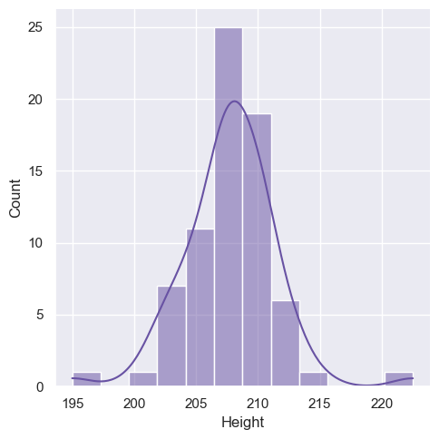

```r
# Python
sns.displot(x = 'Height', data = nba_stats_c, kde = True, color = my_color);
```

```r
# Python
nba_stats_c['Height'][446] = nba_stats_c.median()['Height']
nba_stats_c['Height'][11] = nba_stats_c.median()['Height']
nba_stats_c['Height'][8] = nba_stats_c.median()['Height']
nba_stats_c['Height'][471] = nba_stats_c.median()['Height']

print(nba_stats_c.median()['Height'])
```

```
207.5
```

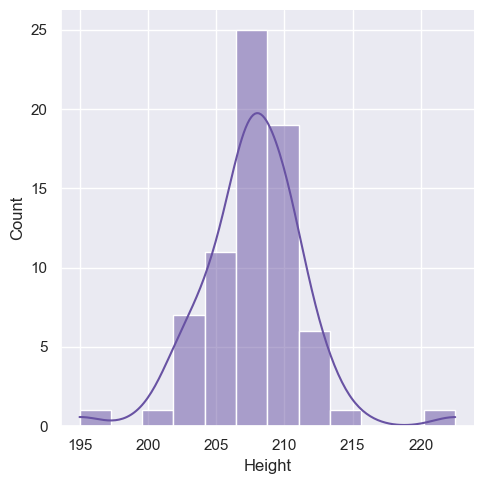

```r
# Python
sns.displot(x = 'Height', data = nba_stats_c, kde = True, color = my_color);
```

Можно сделать вывод о том, что методы заполнения медианными и средними значениями в целом дают довольно близкие результаты.

Проделаем те же действия на R:

```r
# R
nba_stats_c <- filter_data(nba_stats, 'Pos', 'C')
data <- nba_stats_c$Height


# Примечание: в данной таблице другая нумерация, так как удалены пробелы. Поэтому удалю другие значения
nba_stats_c$Height[68]
nba_stats_c$Height[11]
nba_stats_c$Height[8]
nba_stats_c$Height[45]

#Удаляю
nba_stats_c$Height[68] <- NA
nba_stats_c$Height[11] <- NA
nba_stats_c$Height[8] <- NA
nba_stats_c$Height[45] <- NA

data <- mice(nba_stats_c, seed = 31600)
data1 <- complete(data, action = 3)

data1$Height[68]
data1$Height[11]
data1$Height[8]
data1$Height[45]
```

207.5

205

210

202.5

202.5

207.5

195

202.5

## Сгенерировать данные из нормального распределения с различными параметрами и провести анализ с помощью графиков эмпирических функций распределений, квантилей, метода огибающих, а также стандартных процедур проверки гипотез о нормальности (критерии Колмогорова-Смирнова,Шапиро-Уилка,Андерсона-Дарлинга,Крамера фон Мизеса, Колмогорова-Смирнова в модификации Лиллиефорса и Шапиро-Франсия).

```r
# Python
data1 = np.random.normal(0, 2, size = 50)
data2 = np.random.normal(0, 1, size = 50)
data3 = np.random.normal(1, 4, size = 5000)
data4 = np.random.normal(11, 3, size = 5000)
data5 = np.random.normal(1, 1, size = 1000)
```

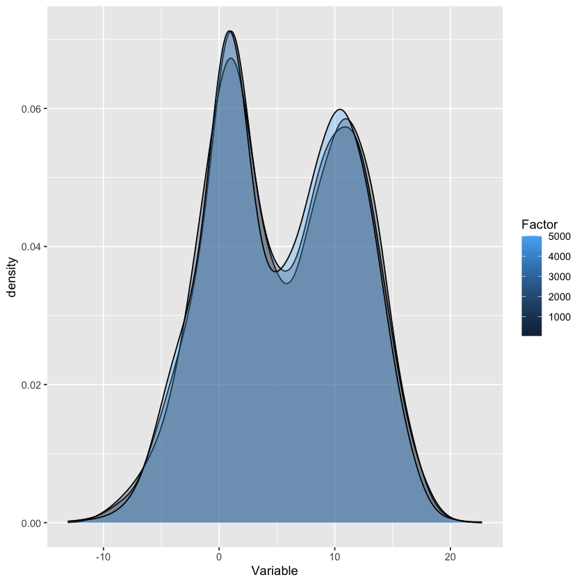

```r
# R
data1 <- rnorm(50, 0, 2)
data2 <- rnorm(50, 0, 1)

data3 <- rnorm(5000, 1, 4)
data4 <- rnorm(5000, 11, 3)

data5 <- rnorm(1000, 1, 1)


library(ggplot2)

norm_vec = data.frame(Factor = rep(c(50, 50,5000, 5000, 1000)),
                                   Variable = c(data1, data2, data3, data4, data5))
ggplot(norm_vec, aes(Variable, group = Factor, fill = Factor)) +
  geom_density(alpha = 0.3)

graph_distr <- function(x, pc, main_name = "")
{
  plot(x,pc, type = "l", col = rgb(0.5, 0.2, 0.7, 0.5), lwd = 2)
  plot(ecdf(x), add = TRUE)
}
```

**Эмпирические функции распределения:**

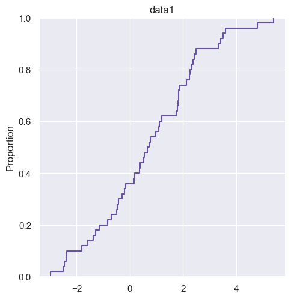

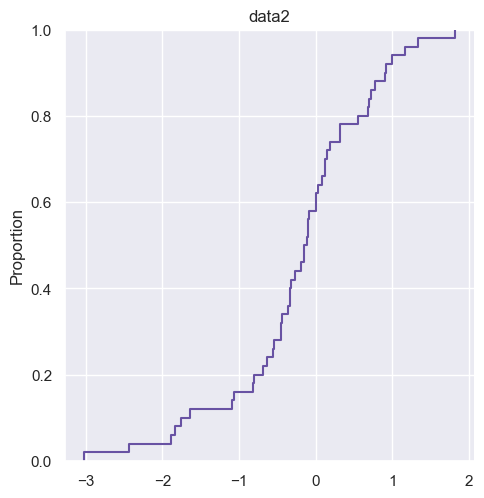

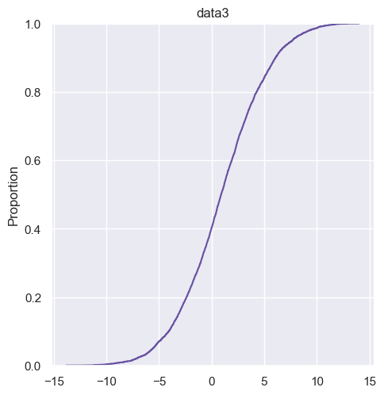

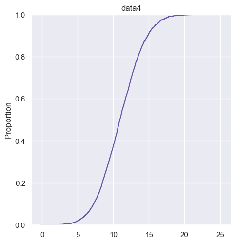

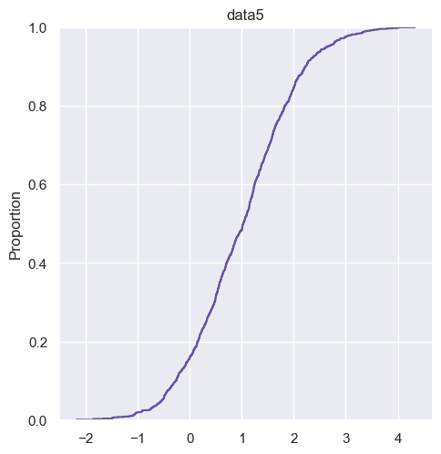

```r
# Python
sns.displot(data = data1, kind = "ecdf", color = my_color).set(title='data1');
sns.displot(data = data2, kind = "ecdf", color = my_color).set(title='data2');
sns.displot(data = data3, kind = "ecdf", color = my_color).set(title='data3');
sns.displot(data = data4, kind = "ecdf", color = my_color).set(title='data4');
sns.displot(data = data5, kind = "ecdf", color = my_color).set(title='data5');
```

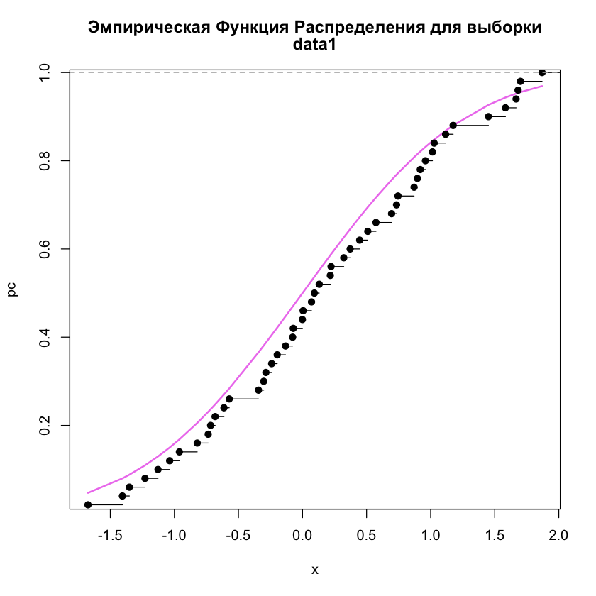

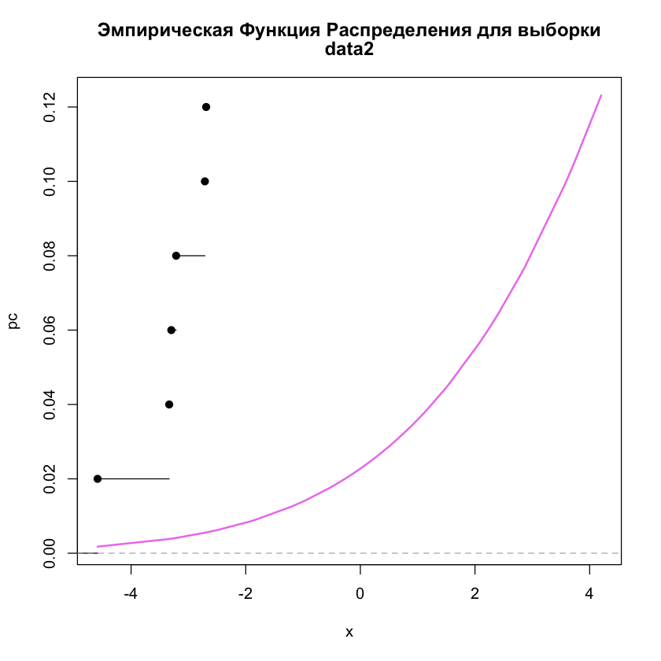

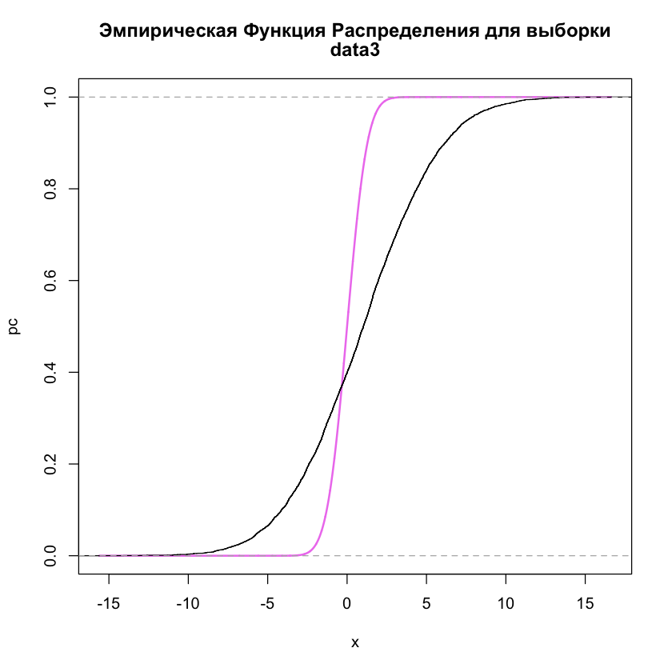

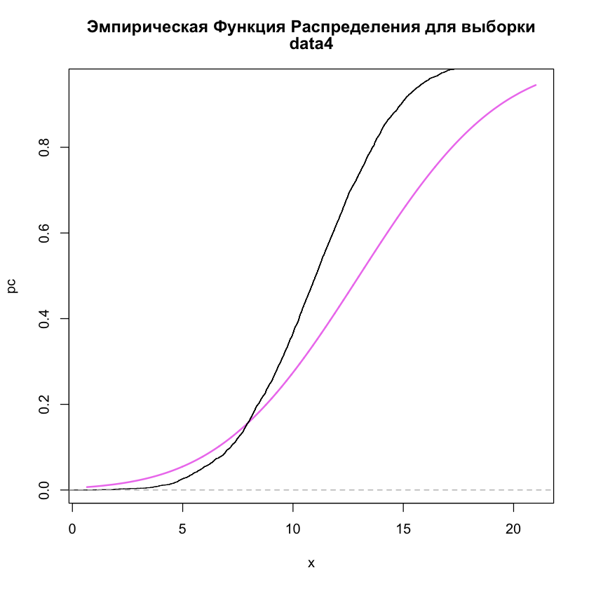

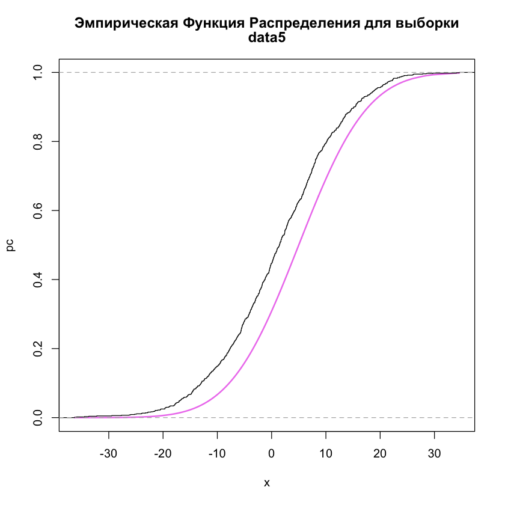

```r
# R
#Выборки малого объема (не более 100)
data1 = rnorm(50, 0, 1)
data2 = rnorm(50, 0, 2)

#Выборки умеренного объема
data3 = rnorm(5000, 1, 4)
data4 = rnorm(5000, 11, 3)
data5 = rnorm(1000, 1, 11)


graph_distr <- function(x, pc, main_name = "")
{
  mn <- paste(c("Эмпирическая Функция Распределения для выборки", main_name))
  plot(x,pc, type = "l", col = "violet", lwd = 2, main = mn)
  plot(ecdf(x), add = TRUE)
}

data1 = sort(data1)
graph_distr(data1, pnorm(data1, mean = 0, sd = 1), "data1")

data2 = sort(data2)
graph_distr(data2, pnorm(data2, mean = 10, sd = 5), "data2")

data3 = sort(data3)
graph_distr(data3, pnorm(data3, mean = 0, sd = 1), "data3")

data4 = sort(data4)
graph_distr(data4, pnorm(data4, mean = 13, sd = 5), "data4")

data5 = sort(data5)
graph_distr(data5, pnorm(data5, mean = 5, sd = 10), "data5")
```